# Homework02

Jorge Ruiz Arocho

2018 M01 24

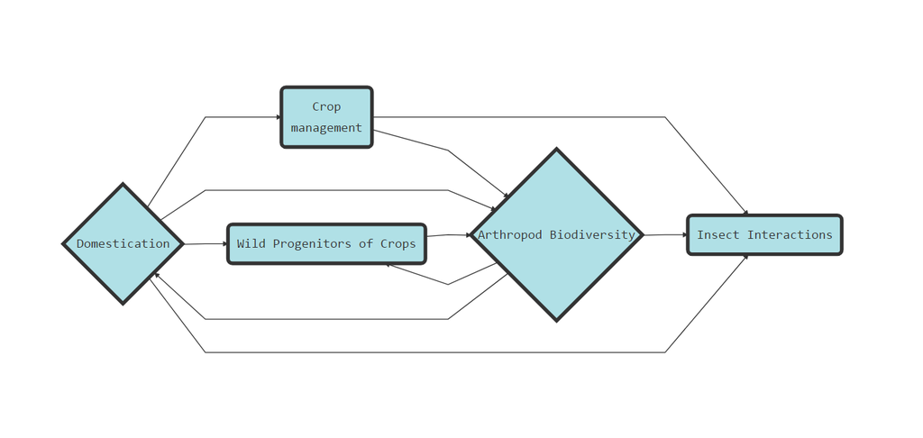

Fig 1. The domestication of crops has an direct effect over the morphological traits of plant wild progenitors. Therefore, we are expecting that this changes will alters arthropod biodiversity that are naturally associated with wild species and subsequently the plant-insect interactions within wild and cultivated crops will be different. At the same time, the proccess of domestication has added abiotic variables (such as pesticides, fungicides, tillages, etc.) that will directly and indirecly affect arthropod biodiversity and insect interactions. We aim to understand how the origins of agriculture have shaped insect agrobiodiversity in the Mesoamerican center of crop origin. We expect to find that the cultivation of domesticated crops has reduced agrobiodiversity.

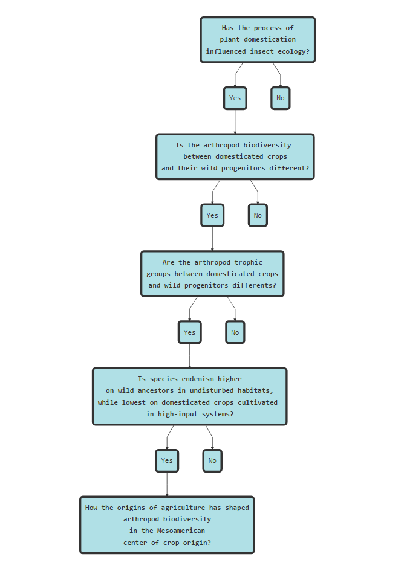

Fig 2. Plant domestication has an direct effect over the insect ecology. Therefore, we are expecting that the insect communities related to cultivated crops and its wild progenitors, as well as their ineractions, will be different (in terms of richness, abundance, endemism, trophic groups, among others). As explained in Fig 1, we aim to understand how the origins of agriculture have shaped insect agrobiodiversity in the Mesoamerican center of crop origin. We expect to find that the cultivation of domesticated crops has reduced agrobiodiversity.